# Introduction to GDSC data

Ricardo Ramirez

1/14/2020

# Introduction

Here we will work with a reduced dataset coming from the Genomics of Drug Sensitivity in Cancer panel from Sanger Institute.

In this notebook we will apply some basic transcriptomics analysis, functional genomics and network biology concepts to answer questions around drug sensitivity in colon cancer.

#### First make sure to install all required dependencies

```r
# If not installed, follow:
# install.packages("package")
library(tidyr)
library(dplyr)
library(purrr)
library(curl)
library(devtools)
library(ggplot2)
# From Bioconductor
# If not installed, follow:
# BiocManager::install("package")
library(viper)
library(progeny)
library(fgsea)
library(OmnipathR)

# To install, please be sure to have either cbc or cplex installed:
# install_github('saezlab/CARNIVAL-Bioconductor-Dev',
#               build_vignettes = FALSE)
library(CARNIVAL)
```

#### Then load all datasets needed for this practical

```r
colon_cells = readRDS("data/colon_cells.rds")
colon_IC50s = readRDS(file = "data/colon_IC50s.rds")
colon_gex = readRDS(file = "data/colon_gex.rds")
load("data/TEDDY_geneSets.ro")

hmarks_gsets = TEDDY_geneSets$MSIGDB_HMARKS
```

1. After what you heard of this dataset, what type of questions could be solved and why network biology + systems biology is useful here?

# Gene analysis / Gene set enrichment analysis

1. Get one drug to test for responses

```r
# Here I choose one drug ("1017") and one panel of drug sensitivity (GDSC1 or GDSC2)
olaparib_IC50s =  colon_IC50s %>% dplyr::filter(DRUG_ID == 1017,
                                                COSMIC_ID %in% colon_cells$COSMIC_ID,
                                                DATASET == "GDSC1")
# Here I filter my cell table to contain only cell lines that were treated with my selected drug
olaparib_cells = colon_cells %>% dplyr::filter(COSMIC_ID %in% olaparib_IC50s$COSMIC_ID)
# Here I add the IDs from my expression matrix to my drug response data
olaparib_IC50s = left_join(olaparib_IC50s, olaparib_cells[,c("DepMap_ID", "COSMIC_ID")])
# Modifying IC50s for analysis
olaparib_IC50s = olaparib_IC50s %>% dplyr::mutate(logIC50 = log(IC50_PUBLISHED,2))
# Same order of IC50s and gene expression
colon_gex_filtered = colon_gex[,olaparib_IC50s$DepMap_ID]
# Filter genes that have more than 50% of data == 0
good_rows = rowSums(colon_gex_filtered == 0) <
            (ncol(colon_gex_filtered))/2
# Final GEX matrix
colon_gex_filtered = colon_gex_filtered[good_rows,]

genes = rownames(colon_gex_filtered)

# Here we perform a linear model of DrugResponse~GeneExpression
# Remember that this is an example and many assumptions have to be
# done to the data!! Don't forget your stats course :-)

lm_summary = data.frame(t(sapply(genes,function(gene){
       modelDF = tibble("Expression" = colon_gex_filtered[gene,],
                        "Response" = olaparib_IC50s$logIC50)

       lmres = lm(Response~Expression,data = modelDF)
       lmres = summary(lmres)$coefficients[2,c(3,4)]
       names(lmres) = c("t","p_value")

       return(lmres)
})))

lm_summary = lm_summary %>%
             mutate("gene" = rownames(lm_summary),
                    "adj_pval" = p.adjust(p_value,"BH")) %>%
             arrange(desc(t))

dim(lm_summary)
```

```
## [1] 16091     4
```

```r
head(lm_summary)
```

```
##          t      p_value    gene   adj_pval
## 1 5.798544 9.864804e-07   ADAP1 0.01240603
## 2 5.658811 1.541984e-06  ARRDC1 0.01240603
## 3 5.228664 6.072445e-06    PKP3 0.01415119
## 4 5.187323 6.923697e-06 TMEM45B 0.01415119
## 5 5.187250 6.925295e-06 TMEM30B 0.01415119
## 6 5.006929 1.225325e-05     SYK 0.01488854
```

2. OK we can make plots just to understand what’s happening
- A positive slope would represent that the expression of the genes contribute to resistance

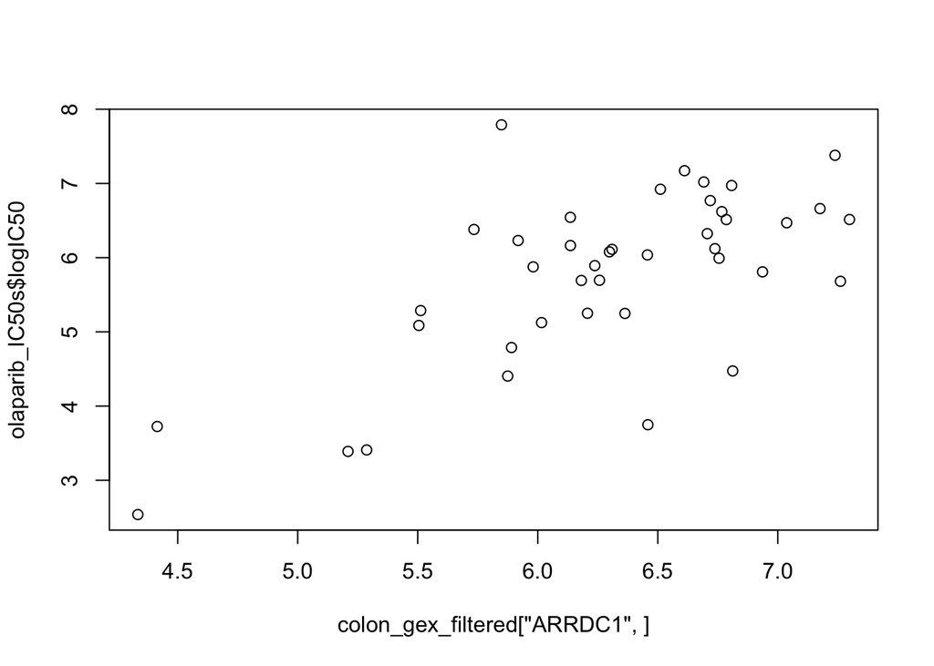

```r
plot(colon_gex_filtered["ARRDC1",],
     olaparib_IC50s$logIC50)
```

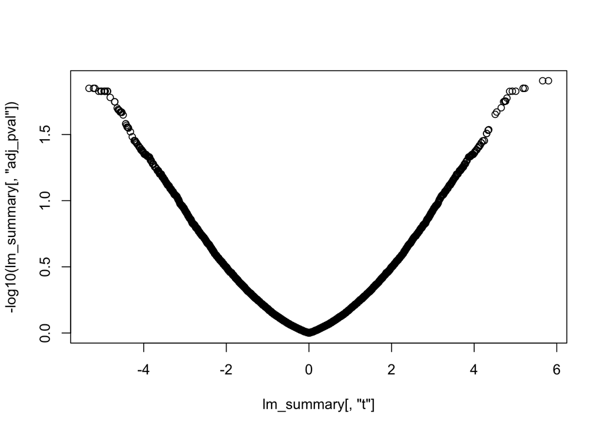

```r
plot(lm_summary[,"t"],
     -log10(lm_summary[,"adj_pval"]))
```

3. What if we wanted to know which processes are involved in resistance?

```r
# Overrepresentation analysis for homework ;)
# Look for hypergeometric tests

# Let's apply GSEA

t_vals = lm_summary$t
names(t_vals) = lm_summary$gene

enrichment_res = fgsea(hmarks_gsets,
                       stats = t_vals,
                       nperm = 1000)

# Let's look at the results

enrichment_res = data.frame(enrichment_res) %>%
                 arrange(desc(abs(NES)))

enrichment_res_filtered = enrichment_res %>%
                          dplyr::filter(pval<0.05)

enrichment_res_filtered[1:5,-8]
```

```
##                     pathway        pval       padj         ES       NES
## 1 INTERFERON_ALPHA_RESPONSE 0.004184100 0.01915709  0.5708387  2.672833
## 2               E2F_TARGETS 0.001207729 0.01515152 -0.5325241 -2.442725
## 3            G2M_CHECKPOINT 0.001212121 0.01515152 -0.4873218 -2.233447
## 4    ESTROGEN_RESPONSE_LATE 0.005747126 0.01915709  0.3945696  2.076185
## 5            MYC_TARGETS_V1 0.001209190 0.01515152 -0.4461670 -2.049022
##   nMoreExtreme size
## 1            0   92
## 2            0  195
## 3            0  192
## 4            0  194
## 5            0  196
```

# TF activities

1. How can we use a regulatory network to infer TF activities?
2. How to infer regulatory networks?

```r
## Function to group Dorothea regulons.
## Input: A data frame containing Dorothea regulons, as stored in
## https://github.com/saezlab/ConservedFootprints/tree/master/data
## Output: Object of class regulon. See viper package.
df2regulon = function(df) {
    regulon = df %>%
        split(.$tf) %>%
        map(function(dat) {
            tf = dat %>% distinct(tf) %>% pull()
            targets = setNames(dat$mor, dat$target)
            likelihood = dat$likelihood
            list(tfmode =targets, likelihood = likelihood)
        })
    return(regulon)
}
```

```r
## We read Dorothea Regulons for Human:
dorothea_regulon_human = read.csv("https://raw.githubusercontent.com/saezlab/ConservedFootprints/master/data/dorothea_benchmark/regulons/dorothea_regulon_human_v1.csv",
                                  stringsAsFactors = F)

## We obtain the regulons based on interactions with confidence level A, B and C
regulon = dorothea_regulon_human %>%
    dplyr::filter(confidence %in% c("A","B","C")) %>%
    df2regulon()

regulon[[1]]
```

```
## $tfmode
## ARHGAP15   ARID5B    ASAP1    CREB5   CTNNA1   CTNNA2   CYP1A1   CYP1A2
##        1        1        1        1        1        1        1        1
##   CYP1B1    DOCK4  EPB41L2      ERG      FOS   FRMD4A     GAS7     KAZN
##        1        1        1        1        1        1        1        1
##    KDM4C   LHFPL2   MAP4K4    MAST4     MID1      MYC    MYO1B    NCOR2
##        1        1        1        1        1        1        1        1
##   NFATC2     NRP2  PHACTR3    PLCB1  RAPGEF4    RBMS1    RUNX1  SIPA1L2
##        1        1        1        1        1        1        1        1
##  SLCO3A1     SOS1    SULF2   TRIM37     TRIO    TRPS1    TSHZ2   UGT1A6
##        1        1        1        1        1        1        1        1
##     UTRN    VGLL4   ZNF217  ZNF385D
##        1        1        1        1
##
## $likelihood
##  [1] 1 1 1 1 1 1 1 1 1 1 1 1 1 1 1 1 1 1 1 1 1 1 1 1 1 1 1 1 1 1 1 1 1 1 1 1 1 1
## [39] 1 1 1 1 1 1
```

#### Getting TF activities and associations with drug response

```r
# Running viper
colon_tfs = viper(eset = colon_gex_filtered,
                  regulon = regulon,
                  verbose = F)
dim(colon_tfs)
```

```
## [1] 178  41
```

```r
colon_tfs[1:5,1:5]
```

```
##       ACH-000971 ACH-000997 ACH-000552 ACH-000651 ACH-000969
## AHR    -1.852873  -1.486913 -1.4202432 -1.0681018  -1.106886
## AR      2.015077   1.903931  2.8659073  2.2097932   2.793560
## ARID2   2.907236   2.966830  2.4487810  2.5052255   3.431550
## ARNT   -1.348722  -1.128324 -1.7256026 -1.7981615  -1.707212
## ASCL1  -1.437433  -1.577679 -0.8102793 -0.2542809  -1.403888
```

```r
tfs = rownames(colon_tfs)

#Running linear models
tfs_lm_summary = data.frame(t(sapply(tfs,function(tf){
       modelDF = tibble("Expression" = colon_tfs[tf,],
                        "Response" = olaparib_IC50s$logIC50)

       lmres = lm(Response~Expression,data = modelDF)
       lmres = summary(lmres)$coefficients[2,c(3,4)]
       names(lmres) = c("t","p_value")

       return(lmres)
})))

tfs_lm_summary = tfs_lm_summary %>%
                 mutate("TF" = rownames(tfs_lm_summary),
                        "adj_pval" = p.adjust(p_value,"BH")) %>%

                 arrange(desc(t)) %>%
                 dplyr::filter(p_value<0.05)

dim(tfs_lm_summary)
```

```
## [1] 42  4
```

```r
head(tfs_lm_summary)
```

```
##          t      p_value    TF    adj_pval
## 1 4.530616 5.438153e-05  KLF5 0.009679912
## 2 4.000079 2.737925e-04  BCL3 0.024367536
## 3 3.689761 6.838472e-04 GRHL2 0.036733140
## 4 3.470509 1.283868e-03 TFAP4 0.043261936
## 5 3.378412 1.664911e-03  ELF3 0.043261936
## 6 3.209700 2.659188e-03 KLF13 0.043863609
```

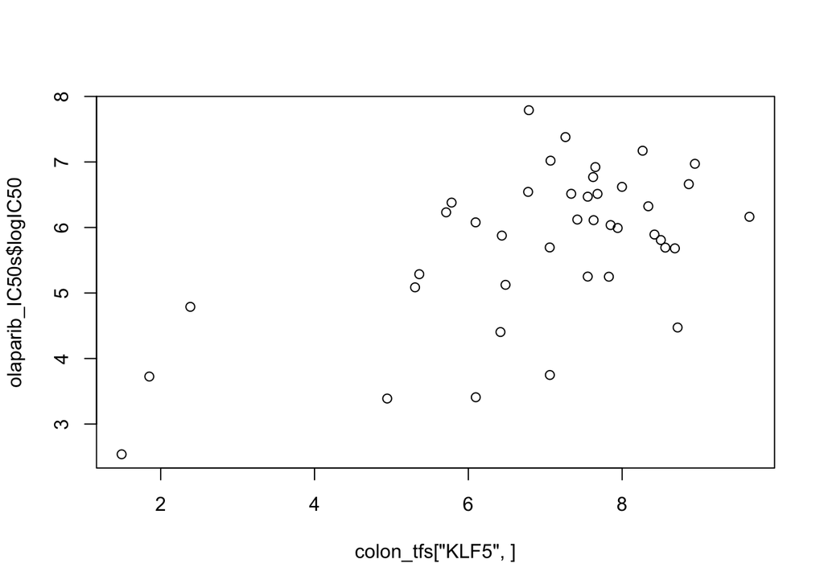

```r
plot(colon_tfs["KLF5",],
     olaparib_IC50s$logIC50)
```

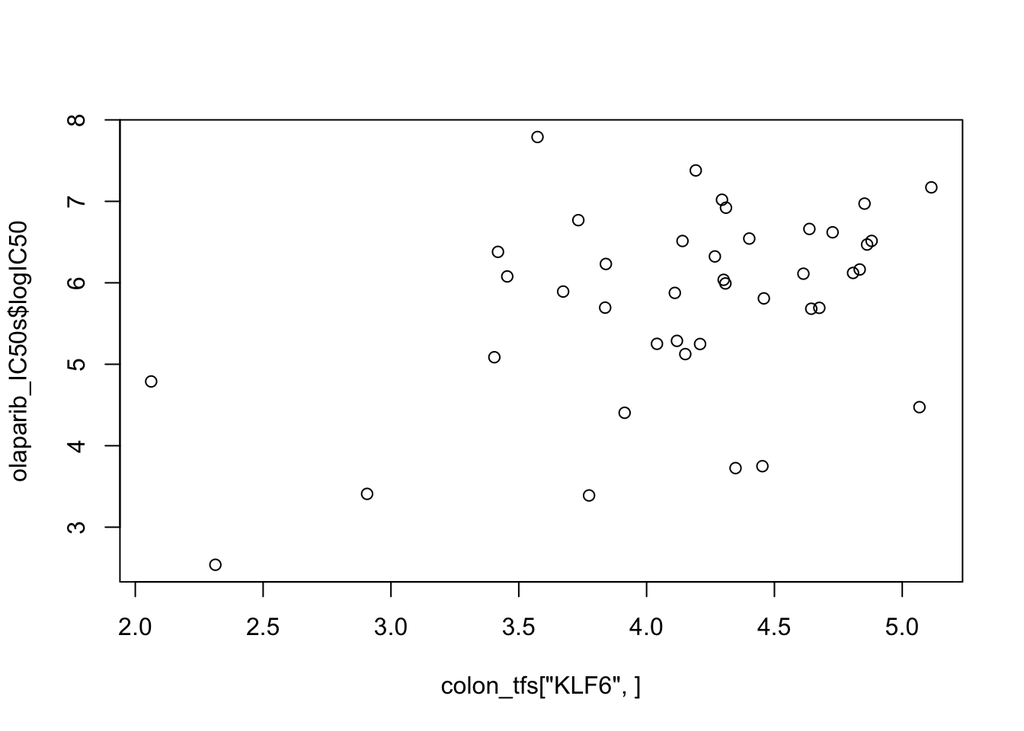

```r
plot(colon_tfs["KLF6",],
     olaparib_IC50s$logIC50)
```

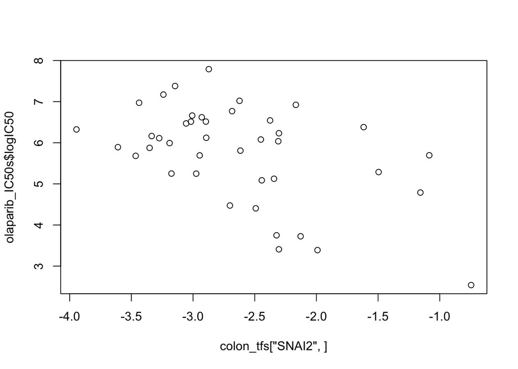

```r
plot(colon_tfs["SNAI2",],
     olaparib_IC50s$logIC50)
```

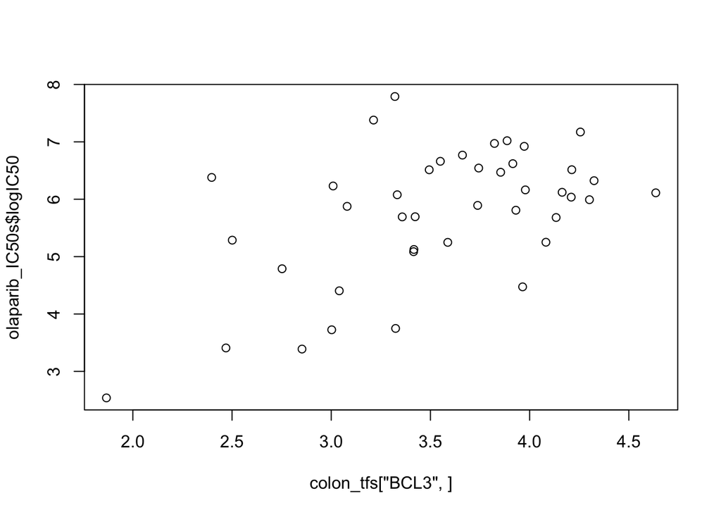

```r
plot(colon_tfs["BCL3",],
     olaparib_IC50s$logIC50)
```

# PROGENy

1. What’s the difference between this approach and GSEA?

#### Here we first calculate pathway activities and then we associate them with drug response

```r
progeny_colon = t(progeny(expr = colon_gex_filtered))
progeny_colon[1:5,1:5]
```

```
##          ACH-000971 ACH-000997 ACH-000552  ACH-000651 ACH-000969
## EGFR      2.2191608 -0.8793979 -0.6830227  0.03662232 -0.7147575
## Hypoxia   1.1401897  1.1202139 -0.0337056 -0.52784576 -1.1319620
## JAK.STAT -0.8016623 -0.3573340 -0.8646512 -1.09848164 -1.0540894
## MAPK      2.3998654 -0.4716654  0.0338391  0.38543514  0.1196614
## NFkB     -0.9684414 -1.3288449 -0.9274415 -1.46951129 -0.6615875
```

```r
pathways = rownames(progeny_colon)

path_lm_summary = data.frame(t(sapply(pathways,function(pathway){
       modelDF = tibble("Expression" = progeny_colon[pathway,],
                        "Response" = olaparib_IC50s$logIC50)

       lmres = lm(Response~Expression,data = modelDF)
       lmres = summary(lmres)$coefficients[2,c(3,4)]
       names(lmres) = c("t","p_value")

       return(lmres)
})))

path_lm_summary = path_lm_summary %>%
                 mutate("Pathway" = rownames(path_lm_summary),
                        "adj_pval" = p.adjust(p_value,"BH")) %>%
                 arrange(desc(t)) %>%
                 dplyr::filter(p_value<0.1)

dim(path_lm_summary)
```

```
## [1] 4 4
```

```r
path_lm_summary
```

```
##           t    p_value Pathway   adj_pval
## 1  2.644805 0.01171797   Trail 0.04296590
## 2 -1.906574 0.06396301    TGFb 0.17589827
## 3 -2.691103 0.01043331    VEGF 0.04296590
## 4 -3.512400 0.00113964    PI3K 0.01253604
```

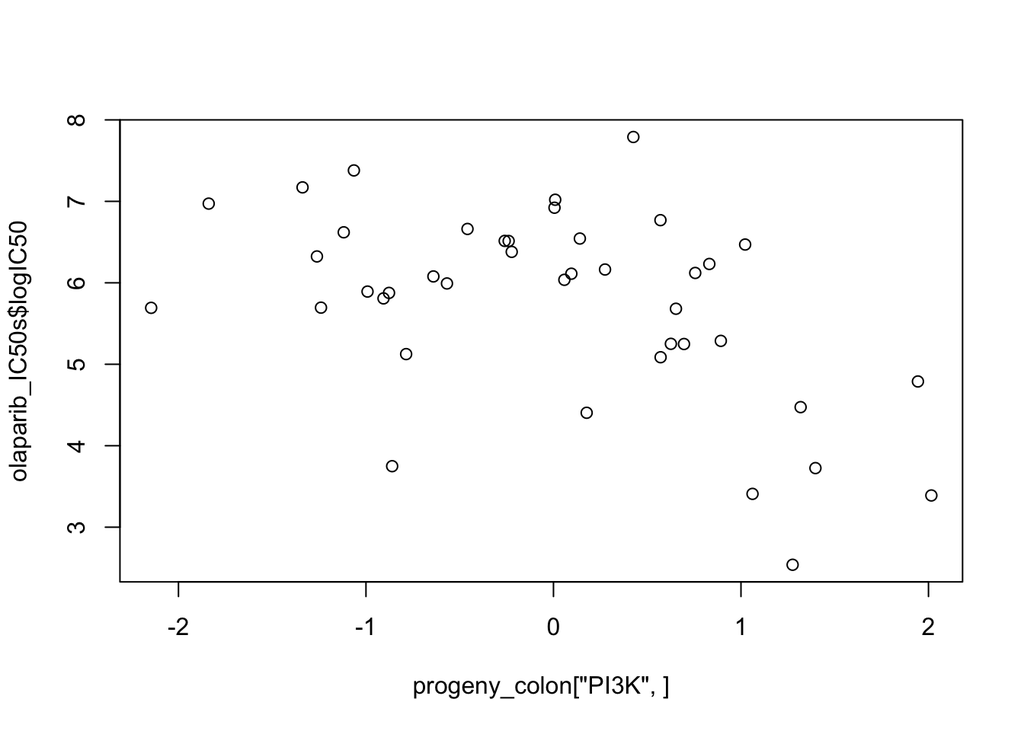

```r
plot(progeny_colon["PI3K",],
     olaparib_IC50s$logIC50)
```

#### Comparison with GSEA

```r
enrichment_res_filtered$pathway
```

```
##  [1] "INTERFERON_ALPHA_RESPONSE"         "E2F_TARGETS"
##  [3] "G2M_CHECKPOINT"                    "ESTROGEN_RESPONSE_LATE"
##  [5] "MYC_TARGETS_V1"                    "ESTROGEN_RESPONSE_EARLY"
##  [7] "TNFA_SIGNALING_VIA_NFKB"           "EPITHELIAL_MESENCHYMAL_TRANSITION"
##  [9] "INTERFERON_GAMMA_RESPONSE"         "ANGIOGENESIS"
## [11] "CHOLESTEROL_HOMEOSTASIS"           "P53_PATHWAY"
## [13] "OXIDATIVE_PHOSPHORYLATION"         "APOPTOSIS"
## [15] "DNA_REPAIR"                        "WNT_BETA_CATENIN_SIGNALING"
## [17] "SPERMATOGENESIS"                   "MYC_TARGETS_V2"
## [19] "KRAS_SIGNALING_UP"                 "IL2_STAT5_SIGNALING"
## [21] "MTORC1_SIGNALING"                  "HYPOXIA"
```

```r
sort(names(hmarks_gsets)[!names(hmarks_gsets) %in%
                       enrichment_res_filtered$pathway])
```

```
##  [1] "ADIPOGENESIS"                    "ALLOGRAFT_REJECTION"
##  [3] "ANDROGEN_RESPONSE"               "APICAL_JUNCTION"
##  [5] "APICAL_SURFACE"                  "BILE_ACID_METABOLISM"
##  [7] "COAGULATION"                     "COMPLEMENT"
##  [9] "FATTY_ACID_METABOLISM"           "GLYCOLYSIS"
## [11] "HEDGEHOG_SIGNALING"              "HEME_METABOLISM"
## [13] "IL6_JAK_STAT3_SIGNALING"         "INFLAMMATORY_RESPONSE"
## [15] "KRAS_SIGNALING_DN"               "MITOTIC_SPINDLE"
## [17] "MYOGENESIS"                      "NOTCH_SIGNALING"
## [19] "PANCREAS_BETA_CELLS"             "PEROXISOME"
## [21] "PI3K_AKT_MTOR_SIGNALING"         "PROTEIN_SECRETION"
## [23] "REACTIVE_OXIGEN_SPECIES_PATHWAY" "TGF_BETA_SIGNALING"
## [25] "UNFOLDED_PROTEIN_RESPONSE"       "UV_RESPONSE_DN"
## [27] "UV_RESPONSE_UP"                  "XENOBIOTIC_METABOLISM"
```

# Carnival

1. What’s the use of network contextualization?
2. Are mechanistic insights worth in the study we are doing?

Be sure to have installed one of the solvers for CARNIVAL to work

#### Get prior knowledge

```r
## We select interactions for mice
AllInteractions = import_Omnipath_Interactions()

## We transform to the format needed by CARNIVAL. We just keep signed and
## directed interactions
SignedDirectedInteractions <- filter(AllInteractions, is_directed==1) %>%
  filter(is_stimulation ==1 | is_inhibition == 1)

InputCarnival <- bind_rows(
  (SignedDirectedInteractions %>%
  filter(is_stimulation == 1 & is_inhibition == 0) %>%
  transmute(source_genesymbol, interaction = 1, target_genesymbol)),
  (SignedDirectedInteractions %>%
     filter(is_stimulation == 0 & is_inhibition == 1) %>%
     transmute(source_genesymbol, interaction = -1, target_genesymbol))) %>%
  distinct()

## We have to be careful with the gene names with a "-". CPLEX gets crazy.
InputCarnival$source_genesymbol <-
  gsub("-","_",InputCarnival$source_genesymbol)
InputCarnival$target_genesymbol <-
  gsub("-","_",InputCarnival$target_genesymbol)

#InputCarnival[,1] = toupper(InputCarnival[,1])
#InputCarnival[,3] = toupper(InputCarnival[,3])

bad_int = which(duplicated(paste(InputCarnival[,1],InputCarnival[,3])))
InputCarnival = InputCarnival[-bad_int,]
```

#### Get dorothea results of one cell line

```r
most_sensitive = data.frame(t(sort(colon_tfs[,"ACH-000491"])))
rownames(most_sensitive) = "NES"
```

#### Run Carnival

```r
##  We run CARNIVAL for one of the cells
CarnivalResults = runCARNIVAL(solverPath="/Users/ricardoramirez/Desktop/cplex",
                                     netObj=InputCarnival,
                                     measObj=most_sensitive,
                                     dir_name="Results_CARNIVAL",
                                     nodeID = 'gene',
                                     timelimit = 600,
                                     solver = "cplex")

write.table(CarnivalResults$weightedSIF,col.names = T,row.names = F,
            sep = ",", file = "data/network_example.csv", quote = F)

write.table(CarnivalResults$nodesAttributes,col.names = T,row.names = F,
            sep = ",", file = "data/network_example_nodes.csv", quote = F)

saveRDS(CarnivalResults, file = "data/carnival_results.rds")
```

#### After running carnival…

```r
CarnivalResults = readRDS(file = "data/carnival_results.rds")
net = data.frame(CarnivalResults$weightedSI,
                 stringsAsFactors = F)
nodes = data.frame(CarnivalResults$nodesAttributes,
                   stringsAsFactors = F) %>%
        mutate(act_sign = sign(as.numeric(AvgAct)))

head(net)
```

```
##     Node1 Sign   Node2 Weight
## 1    CDK2    1   FOXM1    100
## 2  MAP2K1    1   FOXM1    100
## 3   TRAF6    1   NR2C2     80
## 4   TRAF6    1    AKT1     80
## 5  MAP2K1    1 RPS6KA2     80
## 6 RPS6KA2    1    ETV1     80
```

```r
head(nodes)
```

```
##     Node ZeroAct UpAct DownAct AvgAct NodeType act_sign
## 1   SPI1       0     0     100   -100        T       -1
## 2  NFKB1       0     0     100   -100        T       -1
## 3 PRDM14       0     0     100   -100        T       -1
## 4   MXI1       0     0     100   -100        T       -1
## 5   SOX2       0     0     100   -100        T       -1
## 6  TBX21     100     0       0      0        T        0
```

#### Let’s make some questions to the network

Are active nodes enriched for a function?

#### Code for hypergeometric test

```r
## Function to perform Hypergeometric Tests for gene set enrichment
## Input:
## geneList = query gene list to enrich
## Annotation_DB = a list of gene sets to enrich in geneList
## Output: data frame with results

GSE_analysis = function(geneList,Annotation_DB){

  geneList = geneList[geneList %in% unique(unlist(Annotation_DB))]

  ResultsDF = matrix(0,nrow = length(Annotation_DB),ncol = 5)
  rownames(ResultsDF) = names(Annotation_DB)
  colnames(ResultsDF) = c("GenesInPathway","GenesInList","GeneNames","p_value","corr_p_value")

  DB_genecontent = length(unique(unlist(Annotation_DB)))

  GenesDB = DB_genecontent
  SelectedGenes = length(geneList)

  for(gset in rownames(ResultsDF)){
    GP = length(Annotation_DB[[gset]])
    GL = length(intersect(Annotation_DB[[gset]],geneList))

    ResultsDF[gset,"GenesInList"] = GL
    ResultsDF[gset,"GenesInPathway"] = GP
    ResultsDF[gset,"GeneNames"] = paste(intersect(Annotation_DB[[gset]],geneList),collapse = ",")
    #ResultsDF[gset,"p_value"] = HypergeometricTest(overRepres = TRUE,N = N,K = K,n = n,k = k)
    ResultsDF[gset,"p_value"] = phyper(q=GL - 1, m=GP, n=GenesDB-GP, k=SelectedGenes, lower.tail = FALSE, log.p = FALSE)
  }

  ResultsDF[,"corr_p_value"] = p.adjust(ResultsDF[,"p_value"],method = "BH")
  ResultsDF = data.frame(ResultsDF,stringsAsFactors = F)
  ResultsDF = ResultsDF[order(ResultsDF[,"p_value"]),]

  return(ResultsDF)

}
```

```r
active_nodes = nodes %>% filter(act_sign == 1)

#Hypergeometric test
head(GSE_analysis(geneList = active_nodes[[1]],
             Annotation_DB = hmarks_gsets))
```

```
##                                 GenesInPathway GenesInList
## G2M_CHECKPOINT                             199           8
## PI3K_AKT_MTOR_SIGNALING                    104           4
## TNFA_SIGNALING_VIA_NFKB                    198           5
## ALLOGRAFT_REJECTION                        199           5
## REACTIVE_OXIGEN_SPECIES_PATHWAY             47           2
## INTERFERON_GAMMA_RESPONSE                  198           4
##                                                                 GeneNames
## G2M_CHECKPOINT                  E2F1,SFPQ,MYBL2,MYC,HIF1A,E2F4,BCL3,MEIS2
## PI3K_AKT_MTOR_SIGNALING                              AKT1,E2F1,CDK2,SMAD2
## TNFA_SIGNALING_VIA_NFKB                           JUNB,KLF6,MYC,BCL6,BCL3
## ALLOGRAFT_REJECTION                             BCL3,HIF1A,F2R,AKT1,IKBKB
## REACTIVE_OXIGEN_SPECIES_PATHWAY                                 JUNB,GLRX
## INTERFERON_GAMMA_RESPONSE                          IRF2,CIITA,CASP7,HIF1A
##                                              p_value       corr_p_value
## G2M_CHECKPOINT                  0.000215702528235867 0.0107851264117934
## PI3K_AKT_MTOR_SIGNALING           0.0114097579343827  0.285243948359567
## TNFA_SIGNALING_VIA_NFKB           0.0254825041028099   0.32472585553807
## ALLOGRAFT_REJECTION               0.0259780684430456   0.32472585553807
## REACTIVE_OXIGEN_SPECIES_PATHWAY   0.0607437380591162  0.607437380591162
## INTERFERON_GAMMA_RESPONSE         0.0873229269237448  0.623735192312463
```

Are inactive ones?

```r
inactive_nodes = nodes %>% filter(act_sign == -1)

#Hypergeometric test
head(GSE_analysis(geneList = inactive_nodes[[1]],
             Annotation_DB = hmarks_gsets))
```

```
##                           GenesInPathway GenesInList
## INTERFERON_GAMMA_RESPONSE            198           7
## TNFA_SIGNALING_VIA_NFKB              198           7
## PANCREAS_BETA_CELLS                   40           3
## IL6_JAK_STAT3_SIGNALING               86           4
## COMPLEMENT                           193           5
## ALLOGRAFT_REJECTION                  199           5
##                                                         GeneNames
## INTERFERON_GAMMA_RESPONSE STAT1,STAT2,JAK2,DHX58,IRF4,NFKB1,STAT3
## TNFA_SIGNALING_VIA_NFKB     JUN,RELB,ETS2,KDM6B,NFKB1,NR4A1,CEBPB
## PANCREAS_BETA_CELLS                               PAX6,PDX1,FOXO1
## IL6_JAK_STAT3_SIGNALING                     STAT1,STAT3,STAT2,JUN
## COMPLEMENT                          PPP2CB,JAK2,GATA3,CEBPB,HNF4A
## ALLOGRAFT_REJECTION                     STAT1,IRF4,SPI1,JAK2,ETS1
##                                       p_value      corr_p_value
## INTERFERON_GAMMA_RESPONSE 0.00448435979464611 0.112108994866153
## TNFA_SIGNALING_VIA_NFKB   0.00448435979464611 0.112108994866153
## PANCREAS_BETA_CELLS       0.00849875918034707 0.141645986339118
## IL6_JAK_STAT3_SIGNALING    0.0126888469607111 0.158610587008889
## COMPLEMENT                 0.0527266947518286 0.489362708045658
## ALLOGRAFT_REJECTION         0.058723524965479 0.489362708045658
```

Are active nodes upregulated?

Are inactive nodes?

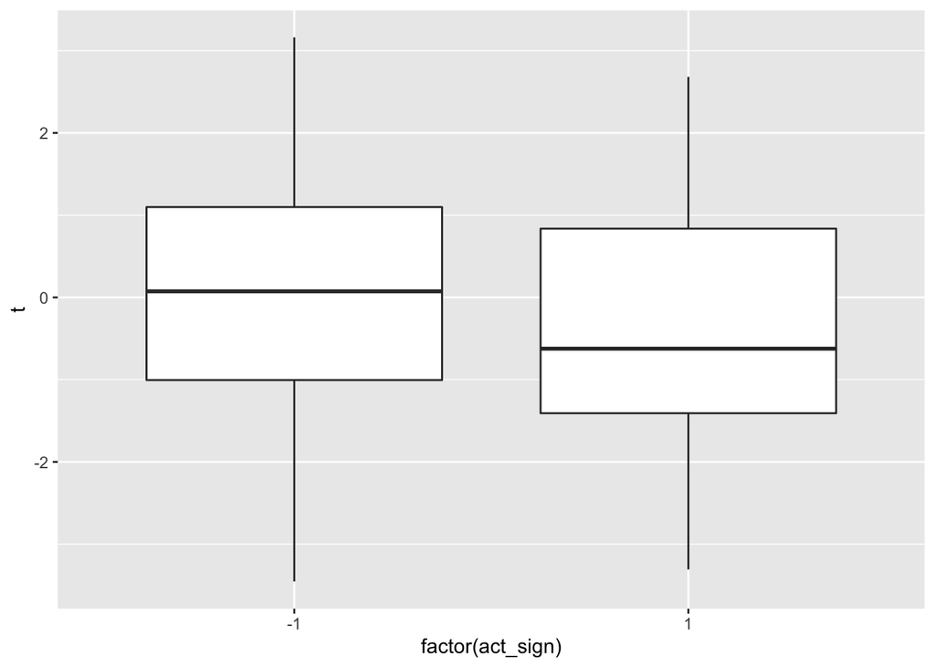

```r
most_sensitive = data.frame(t(sort(colon_tfs[,"ACH-000491"])))
rownames(most_sensitive) = "NES"

useful_nodes = nodes %>% filter(act_sign != 0) %>%
               left_join(lm_summary,
                         by = c("Node"="gene"))

useful_nodes %>% ggplot(aes(x=factor(act_sign), y = t)) + geom_boxplot()
```

```r
summary(lm(t ~ factor(act_sign),data = useful_nodes))
```

```
##
## Call:
## lm(formula = t ~ factor(act_sign), data = useful_nodes)
##
## Residuals:
##     Min      1Q  Median      3Q     Max
## -3.4645 -1.0156 -0.0211  1.1097  3.1517
##
## Coefficients:
##                   Estimate Std. Error t value Pr(>|t|)
## (Intercept)         0.0106     0.1348   0.079   0.9374
## factor(act_sign)1  -0.3857     0.2131  -1.811   0.0719 .
## ---
## Signif. codes:  0 '***' 0.001 '**' 0.01 '*' 0.05 '.' 0.1 ' ' 1
##
## Residual standard error: 1.4 on 178 degrees of freedom
##   (14 observations deleted due to missingness)
## Multiple R-squared:  0.01808,    Adjusted R-squared:  0.01257
## F-statistic: 3.278 on 1 and 178 DF,  p-value: 0.0719
```

# Now let’s move to cytoscape…